# Pop Songs Network Analysis

# By Group 1: Kaixuan Han, Ashley Garbaccio, and Brenden Moore

# Content

### 1.Introduction

### 2.Data

### 3.Analysis

### 4.Conlcusion

# Ⅰ. Introduction

#### In the vibrant pop music industry, there lies a complex, interconnected network that is often overlooked by the casual listener. This network is comprised not only of artists but also the essential producers who breathe life into their songs. We wanted to evaluate the relationships between producers who have produced the Top 30 Pop songs of 2022 and answer questions like: Which producers are the most connected and influential? If we are making a recommendation to an artist that wants a song in the Top 30 charts and a Grammy award, which producer(s) should they hire? In this report, we dive into a detailed network analysis, illuminating the collaboration among producers and patterns that underpin this dynamic landscape.

# Ⅱ. Data

#### The analysis is founded upon two integral datasets of top 52 pop song producers extracted from the billboard ranking: the first being an adjacency matrix which delineates the collaboration history among producers, and the second, a comprehensive attributes list providing details about each producer. The attribute list encompasses gender, an indicator of whether they have achieved a Grammy award, the count of Grammy awards received, and the frequency of their Grammy nominations.

#### The following are the sample of the two data sets.

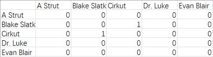

Figure 1. Adjacency matrix that delineates the collaboration history among producers

#### ‘1’ represents that the two producer have collaborated with each other while ‘0’ represents they have not. The diagonal values are all ‘0’ since whether a producer has collaborated with himself is meaningless.

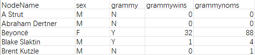

Figure 2. Attributes of producers

# Ⅲ. Analysis

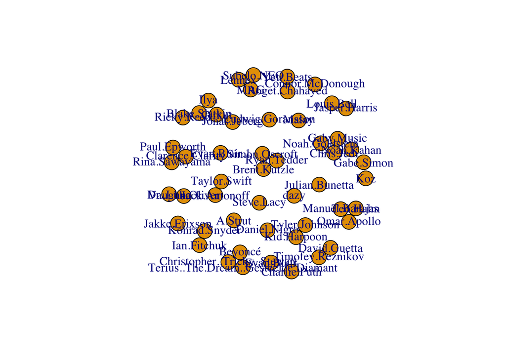

```r
#read the data

#Make an undirected graph and plot it; use set.seed(1234)

library(igraph)
df <- read.csv("Pop_Adjacency_Matrix.csv", row.names = 1)
mat <- as.matrix(df)

g <- graph_from_adjacency_matrix(mat, mode="undirected")

set.seed(1234)
plot(g)
```

## Histogram of the Pop Producers Network

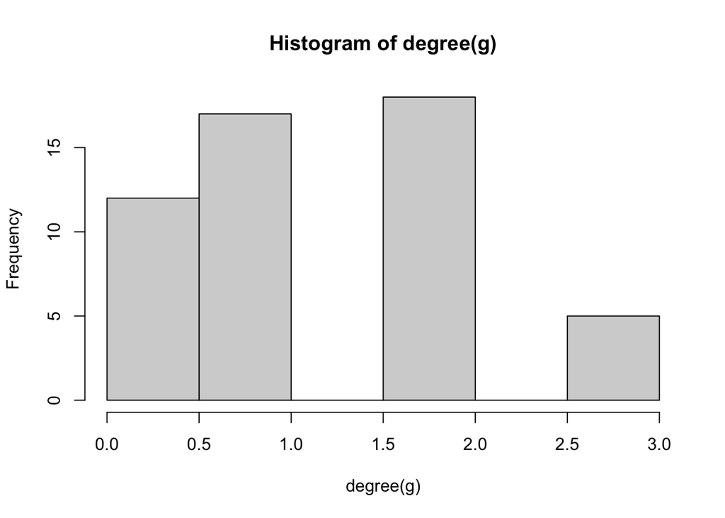

```r
hist(degree(g))
```

## Betweenness

```r
sort(betweenness(g))
```

```
##                              A.Strut                             Dr..Luke
##                                  0.0                                  0.0
##                           Evan.Blair                          Ian.Fitchuk
##                                  0.0                                  0.0
##                                 Ilya                        Jack.Antonoff
##                                  0.0                                  0.0
##                        Jasper.Harris                         Jonas.Jeberg
##                                  0.0                                  0.0
##                          Kid.Harpoon                        Konrad.Snyder
##                                  0.0                                  0.0
##                           Louis.Bell                           Ricky.Reed
##                                  0.0                                  0.0
##                           Steve.Lacy                         Taylor.Swift
##                                  0.0                                  0.0
##                        Tyler.Johnson                        Vaughn.Oliver
##                                  0.0                                  0.0
##                          Ryan.Tedder                                  Koz
##                                  0.0                                  0.0
##                           Subelo.NEO                              Beyoncé
##                                  0.0                                  0.0
##                         Daniel.Nigro                       Julian.Bunetta
##                                  0.0                                  0.0
##                                 dazy                         David.Guetta
##                                  0.0                                  0.0
##                                Malay                           Yeti.Beats
##                                  0.0                                  0.0
##                         Evan.Blair.1                        Jakke.Erixson
##                                  0.0                                  0.0
##                         Charlie.Puth                        Rina.Sawayama
##                                  0.0                                  0.0
##                       Manuel.Barajas                     Ludwig.Goransson
##                                  0.0                                  0.0
##                     Connor.McDonough                         Brent.Kutzle
##                                  0.0                                  0.0
##                               Lennex Terius..The.Dream..Gesteelde.Diamant
##                                  0.0                                  0.0
##                     Timofey.Reznikov                       Noah.Goldstein
##                                  0.0                                  0.0
##                       Roget.Chahayed                         Paul.Epworth
##                                  0.0                                  0.0
##                          Omar.Apollo                        Simon.Oscroft
##                                  0.0                                  0.0
##                                  MAG         Christopher..Tricky..Stewart
##                                  0.0                                  0.0
##                     Clarence.Clarity                             Teo.Halm
##                                  0.0                                  0.0
##                           Chris.Jedi                           Gaby.Music
##                                  1.5                                  1.5
##                        Blake.Slatkin                               Cirkut
##                                  3.0                                  3.0
##                           Gabe.Simon                           Noah.Kahan
##                                  4.0                                  6.0
```

- We wanted to measure the extent to which a producer is on the geodesic paths of all other pairs of nodes in the Top 30 Pop songs network. This helps us answer the question: how important are certain producers in facilitating collaboration and connections between other producers in the network? Noah Kahan and Gabe Simon occupy central positions in this network and act as key connectors for information flow and collaborations in the network.

## Eigenvector Centrality

```r
sort(eigen_centrality(g)$vector)
```

```
##                        Blake.Slatkin                               Cirkut
##                         0.000000e+00                         0.000000e+00
##                             Dr..Luke                          Ian.Fitchuk
##                         0.000000e+00                         0.000000e+00
##                                 Ilya                        Jack.Antonoff
##                         0.000000e+00                         0.000000e+00
##                        Jasper.Harris                         Jonas.Jeberg
##                         0.000000e+00                         0.000000e+00
##                          Kid.Harpoon                        Konrad.Snyder
##                         0.000000e+00                         0.000000e+00
##                           Louis.Bell                           Ricky.Reed
##                         0.000000e+00                         0.000000e+00
##                         Taylor.Swift                        Tyler.Johnson
##                         0.000000e+00                         0.000000e+00
##                        Vaughn.Oliver                              Beyoncé
##                         0.000000e+00                         0.000000e+00
##                         David.Guetta                           Yeti.Beats
##                         0.000000e+00                         0.000000e+00
##                         Brent.Kutzle                     Timofey.Reznikov
##                         0.000000e+00                         0.000000e+00
##                       Roget.Chahayed                        Simon.Oscroft
##                         0.000000e+00                         0.000000e+00
##                                  MAG                          Ryan.Tedder
##                         0.000000e+00                         5.237172e-17
##                           Subelo.NEO                       Manuel.Barajas
##                         5.237172e-17                         5.237172e-17
##                               Lennex         Christopher..Tricky..Stewart
##                         5.237172e-17                         5.237172e-17
##                     Clarence.Clarity                        Rina.Sawayama
##                         5.237172e-17                         1.047434e-16
## Terius..The.Dream..Gesteelde.Diamant                         Paul.Epworth
##                         1.047434e-16                         1.047434e-16
##                          Omar.Apollo                             Teo.Halm
##                         1.047434e-16                         1.047434e-16
##                              A.Strut                           Evan.Blair
##                         1.309293e-16                         1.309293e-16
##                           Steve.Lacy                         Daniel.Nigro
##                         1.309293e-16                         1.309293e-16
##                       Julian.Bunetta                                 dazy
##                         1.309293e-16                         1.309293e-16
##                                Malay                         Evan.Blair.1
##                         1.309293e-16                         1.309293e-16
##                        Jakke.Erixson                         Charlie.Puth
##                         1.309293e-16                         1.309293e-16
##                     Ludwig.Goransson                     Connor.McDonough
##                         1.309293e-16                         1.309293e-16
##                                  Koz                           Gabe.Simon
##                         1.491020e-01                         3.959319e-01
##                       Noah.Goldstein                           Noah.Kahan
##                         7.531702e-01                         9.022722e-01
##                           Chris.Jedi                           Gaby.Music
##                         1.000000e+00                         1.000000e+00
```

- Again, we wanted to measure the influence or importance of a producer in the network based on their connections to other highly connected producers. A higher eigenvector centrality score suggests that a producer is connected to other producers who are themselves well-connected. In this analysis, Chris Jedi, Gaby Music, and Noah Kahan have scores of 1 or very close to 1. These producers are connected to other highly influential producers and occupy important positions in the producer network structure.

## Centralization

```r
# What is the centralization score of the entire network?
centralization.degree(g)$centralization
```

```
## [1] 0.0331825
```

```r
#Obtain the largest component and plot it; please use set.seed(1234)

clu <- components(g)
biggest_cluster_id <- which.max(clu$csize)
vert_ids <- V(g)[clu$membership == biggest_cluster_id]
maincluster <- induced_subgraph(g, vert_ids)
maincluster
```

```
## IGRAPH d741f80 UN-- 6 7 --
## + attr: name (v/c)
## + edges from d741f80 (vertex names):
## [1] Koz           --Gabe.Simon     Gabe.Simon    --Noah.Kahan
## [3] Chris.Jedi    --Noah.Kahan     Chris.Jedi    --Noah.Goldstein
## [5] Chris.Jedi    --Gaby.Music     Noah.Kahan    --Gaby.Music
## [7] Noah.Goldstein--Gaby.Music
```

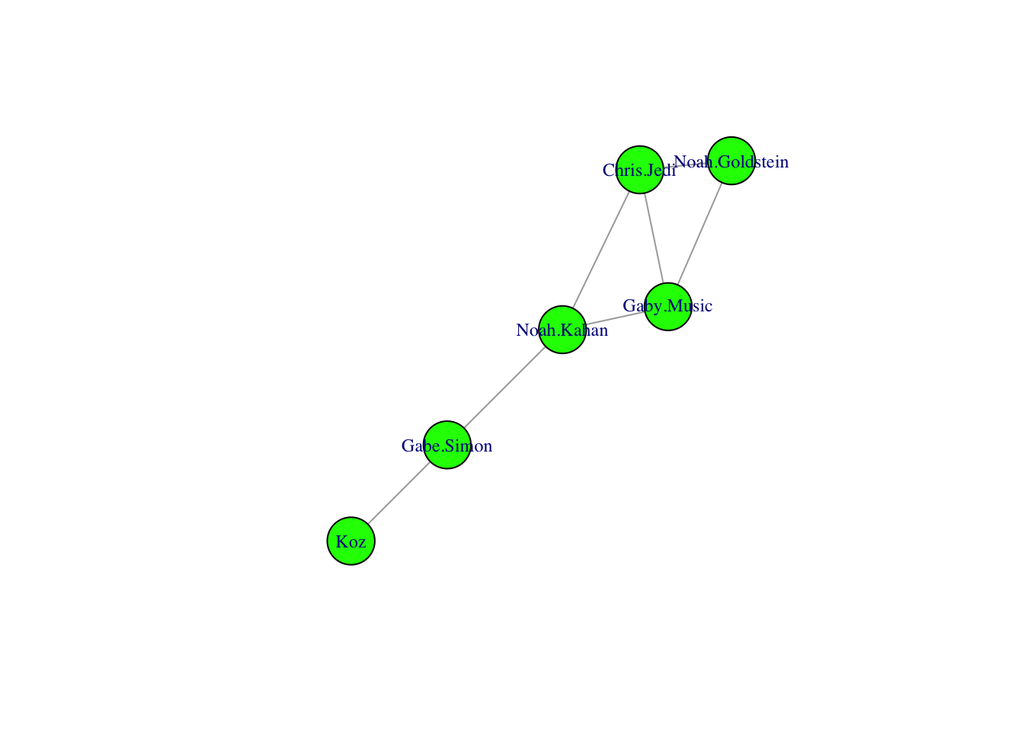

```r
#plot largest cluster

set.seed(1234)
plot(maincluster, vertex.size=25, vertex.label.cex=.75, vertex.color="green")
```

```r
# (d) Obtain the degree distribution of the largest cluster and plot it

degree(maincluster)
```

```
##            Koz     Gabe.Simon     Chris.Jedi     Noah.Kahan Noah.Goldstein
##              1              2              3              3              2
##     Gaby.Music
##              3
```

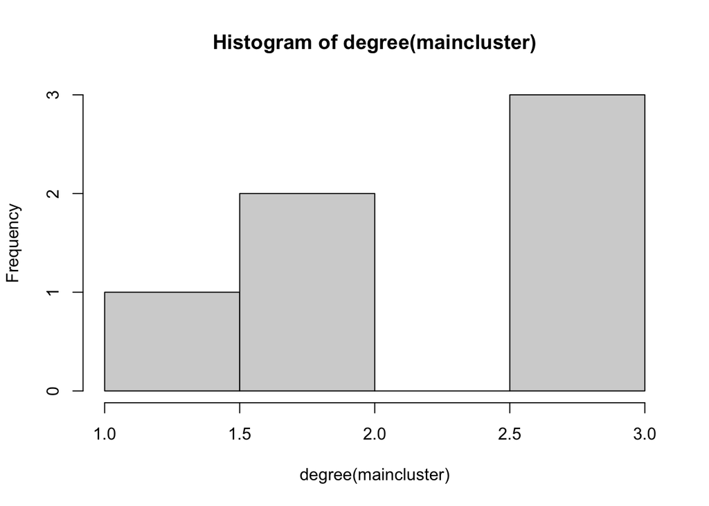

```r
hist(degree(maincluster))
```

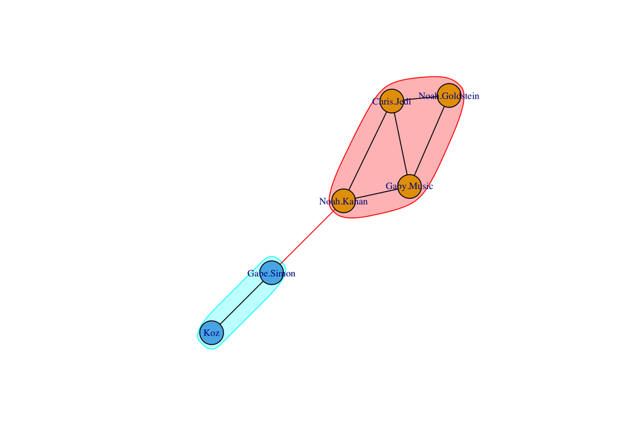

```r
wt <- cluster_walktrap(maincluster, steps=20)

set.seed(1234)
plot(wt, maincluster,
     vertex.size=20, vertex.label.cex=.65, vertex.label.font=15, vertex.color="beige")
```

## Pop Producer Network Attributes

```r
# Read the data
popattr <- read.csv("popattribs.csv", header = T)

# Getting adjacency matrix
adj <- mat %*% t(mat)

# Set diagonal to zero
diag(adj) <- 0

# any two producers must have collaborated with at least 1 other producer
adj <- ifelse(adj >= 1,1,0)
```

```r
#Create igraph object
library(igraph)
g2 <- graph_from_adjacency_matrix(adj, mode="undirected")

# Add attributes, straightforward because order of attributes is same as that of the order of nodes
g2$sex <- popattr$Sex
g2$name <- popattr$Producer.Name
g2$grammy <- popattr$Grammy
g2$grammywins <- popattr$GrammyWins
g2$grammynoms <- popattr$GrammyNoms
```

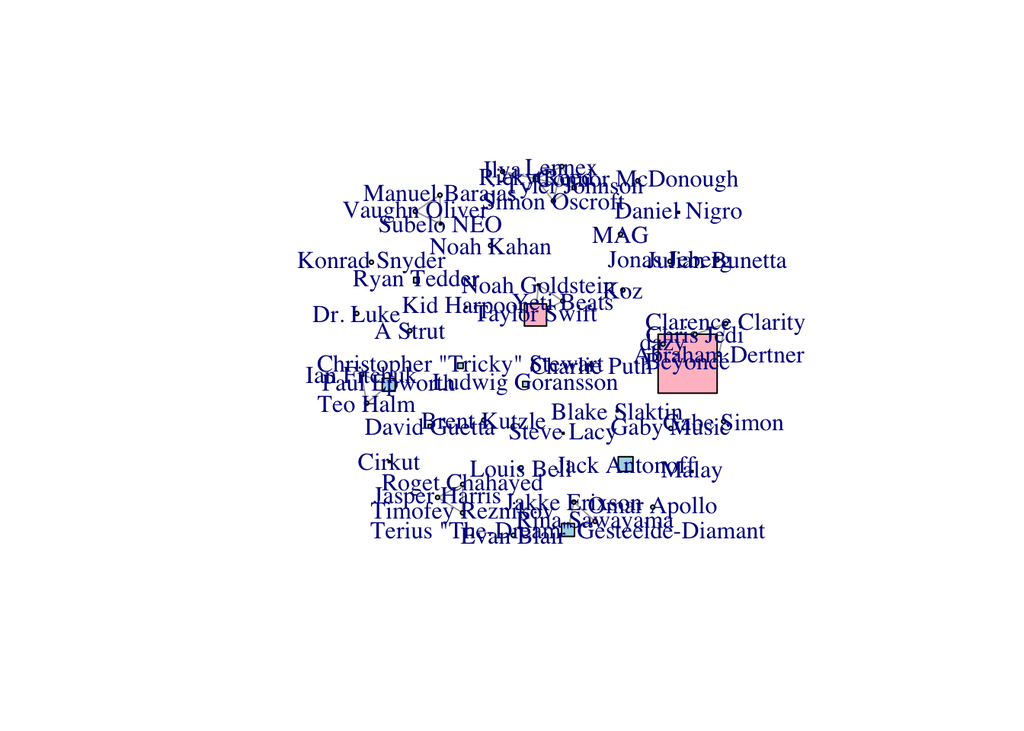

```r
V(g2)$color <- ifelse(g2$sex == "F", "pink", "lightblue")
V(g2)$shape <- ifelse(g2$grammy == "Y", "square", "circle")
set.seed(1234)
plot(g2, vertex.size= g2$grammywins, vertex.label= g2$name)
```

## Homophily Test

```r
assortativity_nominal(g2, as.factor(g2$sex), directed=FALSE)
```

```
## [1] -0.1372549
```

#### The negative assortativity coefficient of sex indicates that producers of different genders tend to collaborate more with each other compared with that of the same gender.

```r
assortativity_nominal(g2, as.factor(g2$grammy), directed=FALSE)
```

```
## [1] -0.1717172
```

#### The negative assortativity coefficient of grammy indicates that producers with grammy tend to collaborate more with those without a grammy.

```r
assortativity(g2, g2$grammywins, directed=FALSE)
```

```
## [1] -0.1480284
```

#### The negative assortativity coefficient of grammywins indicates that music producers with different numbers of Grammy awards won are more likely to collaborate with each other.

```r
assortativity(g2, g2$grammynoms, directed=FALSE)
```

```
## [1] -0.1408163
```

#### The negative assortativity coefficient of grammynoms indicates that music producers with different numbers of Grammy nominations are more likely to collaborate with each other.

## Correlation

```r
v1 <- c(0,0,32,1,0,0,0,3,1,0,0,1,2,0,0,0,0,0,2,0,8,0,0,0,0,1,0,0,0,0,3,0,1,0,1,0,0,7,3,0,0,3,0,1,1,12,0,7,0,2,0,0)

v2 <- c(0,0,88,4,1,4,0,12,2,0,0,3,11,0,8,0,0,2,2,5,18,0,2,0,0,0,0,2,0,10,9,0,1,0,6,0,1,8,10,0,7,11,0,6,1,46,0,21,1,5,1,4)

grammywins <- matrix(v1, nrow = 1, byrow = TRUE)
grammynoms <- matrix(v2, nrow = 1, byrow = TRUE)


rownames(grammywins) <- rownames(grammynoms) <- LETTERS[seq( from = 1, to = 1 )]
colnames(grammywins) <- colnames(grammynoms) <- LETTERS[seq( from = 1, to = 52 )]
```

```r
library(sna)
gcor(grammynoms,grammywins)
```

```
## [1] 0.9694597
```

- This correlation value suggests a strong correlation between Grammy nominations and Grammy wins. Higher values of Grammy nominations are associated with higher values of Grammy wins.